# Module 3: Functions & Packages (Libraries) in R

## **R Functions**

There are many different tasks that we need to do routinely. For instance,

- we need to look at the distribution of a numerical variable in a data set,
- we need to visualize the relationship between two different variables,
- and we need to aggregate a variable by another variable (e.g. aggregating a transactional data by each day).

Since these are routine tasks that many R users need to perform, R has created many different **“FUNCTIONS”** to make things easier for us. Using functions, we don’t need to write a very lengthy code that uses basic R operators (e.g. addition, subtraction, …). Instead, we use the functions to perform the routine tasks. The example below shows how a function is being created:

```r
f1 <- function(x) {
  x + 10
  }
```

The function, f1, takes a value of x and adds 10 to it. To use this function, we need to provide x. Here is how we do it:

```r
f1(1)
```

```
## [1] 11
```

The x that we provided is 1. The output of this function is therefore 11. Below is a more advanced function:

```r
f2 <- function(x,y,z) {
  (x + y)/z
  }
```

Quick test: How many inputs we need to provide to this function? What does f2 do?  
Here is an example:

```r
f2(1,2,3)
```

```
## [1] 1
```

There are many different R functions that are already included in R installation. For instance, the following function will generate a random number from a normal distribution with the mean of 0 and the standard deviation of 1. **“rnorm”** is an R function.

```r
rnorm(1,0,1)
```

```
## [1] -1.521443
```

How can we generate (draw) two random numbers from a normal distribution with mean of 3 and standard deviation of 4?  
Here is the answer:

```r
rnorm(2,3,4)
```

```
## [1] 7.235094 5.437633
```

The general format of this function is **“rnorm(n, mean, sd)”** where “n” is the number of numbers we are willing to draw from the normal distribution, “mean” is the mean of the normal distribution that we are willing to draw from, and “sd” is the standard deviation of the normal distribution that we are willing to draw from.

## **R Packages (Libraries)**

Although there are many functions already included in the original distribution (installation) of R, there are many other functions that the R community has created so far.

- These functions use R’s original operators and functions as well as other functions that were created by R community to further help users perform their analytical tasks more efficiently.
- Functions that are related to the same tasks are put together as a **“package”**.
- These packages contain many different functions and are usually put together to help users to perform certain tasks.

For instance, the package **“randomForest”** is created to help R users to build analytical models based on random forest algorithms.

Throughout this course, we need to use many of these packages to efficiently perform our analytical tasks. To be able to use these packages, we first need to install them in R. The following code installs “randomForest” package.

```r
install.packages("randomForest")
```

Note: In R, a package is a collection of R functions, data and compiled code.

- The location where the packages are stored in our machines is called the library.
- That is, once we install a package on our machine we then call it a library.
- We use “package” and “library” interchangeably throughout this course.

After installing the package (which is now called the library) and before using it, we need to call the library so that R prepares all of the functions in “randomForest” library for us to use. To do so, we run:

```r
library("randomForest")
```

- It is worth noting that we only need to **install a package the first time we are using** that package on a machine.
- After installing the package, we don’t need to reinstall it on the same machine (for instance we don’t need to run install.packages(“randomForest”) again).
  - However, we still need to ask R to prepare the library every time we open R (i.e. we still need to run library(“randomForest”)).

Since each user can create a library, therefore we may have many different libraries that could help us perform the same tasks (e.g. there are different libraries for building random forest models). You may find a comprehensive list of R packages here: [CRAN SITE](https://cran.r-project.org/web/packages/available_packages_by_name.html)

One more way of installing packages is shown in the figure below. By clicking on Tools->Install Packages, a window pops up where we can enter the name of the package and click on Install button.

[figure not shown]

Looking at the output of the installation, the warning message may give us information about the origin and size of the package. We can ignore the warning message(s) we get (if any) if the package is successfully installed.

#### Activity

`dplyr` should appear on the lower right (install the package it if not). Press all the buttons necessary to make the install happen. After you have done the installation, go back to the **Help** tab where you can click on the *Installed Packages* link shown in the figure below.

[figure not shown]

Navigate to the `dplyr` link and click on it so that you get to the help on the `dplyr` package. Two kinds of help are displayed: *Documentation and Help Pages.*

[figure not shown]

The *Help Pages* document facilities that the package `dplyr` in detail. The Documentation is often more useful, because they can contain user guides and *vignettes* that are very useful for people learning about the package. So click on the *User guides*.

[figure not shown]

Click on the *Introduction to dplyr* vignette to see the vignette.

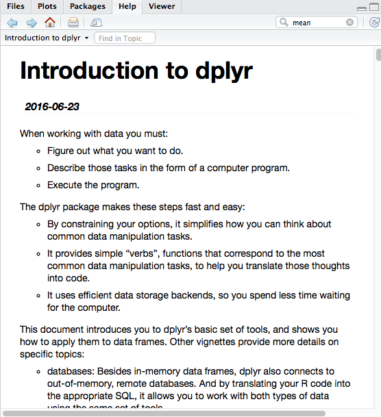

*Vignettes, when present, are indispenable in learning about a package*. Not all packages provide vignettes, however!